# Data Resource Profile: A Florida-scale simulated dataset for developing and benchmarking record-linkage software for cancer registries

Authors

Affiliations

Abraham D. Flaxman

University of Washington

Maybe others?

Anders Alexandersson

University of Miami Miller School of Medicine

Keywords

record linkage, entity resolution, simulated data, cancer registry, benchmark dataset, reproducibility, pseudopeople

## Key Features

- **What is unique:** a large, fully simulated, multi-file dataset for linking individual people, with cross-file ground truth (every record includes a value for matching across files, so missed-match and false-match rates of any method can be computed exactly), designed to capture the record-linkage challenges faced by a Florida-scale cancer data system.
- **Why created:** linkage software for cancer registries must be developed and tested on names, dates of birth, addresses, and Social Security numbers (SSNs), which are the identifiers that confidentiality rules prevent registries from releasing.
- **Details:** a simulated registry of 5,000,000 records drawn from 50,518,675 simulated Florida residents in 2020, 2030, or 2040, with the age and sex distribution of the cases reported to the Florida Cancer Data System, and researcher “finder files” of 500,000 and 100,000 records drawn from residents in 2040.
- **Data linkage:** the larger finder file includes 100,000 people who are also in the registry and the smaller finder file includes 20,000. There is no overlap between the finder files.
- **Main categories of data:** simulated person-level identifiers including name, date of birth, sex, street-address fields, SSN, race/ethnicity, and a diagnosis date on each registry record, with synthetic noise (typos, nicknames, month/day swaps, blanks).
- **Access:** direct download under a permissive license with a DOI.

# 1 Background

A population-based cancer registry holds a record of every cancer diagnosed among the residents of a state or country, and the incidence and survival statistics that cancer control depends on come from those records [1], as does the evidence of disparities in detection and treatment. These records are also the raw material for global estimates of cancer burden, which are assembled from every registry available [2]. The Florida Cancer Data System (FCDS) is one such registry; it has collected cases statewide since 1981 and holds more than seven million records [3].

A researcher or a public health program often has a list of people, such as a cohort of workers, the participants in a screening program, or the enrollees in a clinical trial, and needs to know which of them have cancer; the registry links this list (a “finder file” in FCDS’s vocabulary) to its records and reports the matches [4]. This record linkage can be made based on name, date of birth, address, or even Social Security number (SSN), all of which might be misspelled, out of date, or just missing in some of the records. Missing a match might make it appear that a person stayed healthy when really they developed cancer, while making a false match might make it appear that a person developed a cancer that never occurred. Either error can produce misleading results [5,6].

Improving record linkage for cancer registries is hard because the data that they link is confidential and cannot be openly shared [7]. The confidentiality rules vary from state to state, but none allow enough sharing to optimize a linkage system in the open [8]. Researchers have obtained access to confidential fields through lengthy approval processes, but this can take years and incur substantial expense [9]. Even if registry data is obtained, it does not come with any source of “ground truth” to show which records truly belong together, so the accuracy of a linkage can only be estimated [10].

Simulated datasets can avoid these issues, but so far they have fallen short in other ways. The classic test corpora hold thousands of records, and the generators behind them struggle to go past a million records [11–13]. This is still much smaller than a registry in a large state like Florida. There are large, openly downloadable person files from voter rolls, but these contain only registered voters (which excludes all people under age 18) [14,15]. The one cancer registry benchmark we know of contains comparison scores rather than records, so it cannot exercise blocking or string comparison [16], and the one large microsimulation built to study linkage quality, about 20 million people in a German educational register, was not released with its papers as far as we can find [17]. The simulation this work builds on, pseudopeople, is not tuned to cancer demographics, and its large populations are available only on request [18]. When an FCDS researcher evaluated open-source linkage software in 2023, he used a test file based on pseudopeople that was supplied privately, and in his report, he called for such data to be made more openly available [19].

This data resource, a simulated state cancer registry with two simulated finder files, is our answer to the call for a large-scale dataset for improving cancer registry record linkage. It is a direct download with a digital object identifier (DOI), with no request, approval, or data-use agreement required. Every record includes an identifier that says which unique person it describes, so the missed matches and false matches of a linkage can be counted. The files have the fields that real linkages run on, including SSNs and street addresses, at the scale of a state registry and with errors of the kinds and rates seen at FCDS. The simulated registry mimics the age and sex pattern of FCDS’s reported cases, and the finder files overlap it by known amounts. Because every person in every file is simulated, there is nothing in this data resource that is confidential. The rest of this profile describes how the files were built (Section 2), what is in them and how hard they are to link (Section 3), what they can and cannot stand in for (Section 4), and how to get them (Section 5).

# 2 Methods

## 2.1 Source population and the Florida extract

The records come from pseudopeople, a Python package for generating simulated versions of the datasets on which census-scale record linkage often runs [20]. It uses output from a dynamic microsimulation of the United States, initialized to the size and demographics of the country in 2020 and run forward through 2040 with births, deaths, and migration. Each simulated person (a “simulant” in pseudopeople’s vocabulary) has a `simulant_id` and is observed by simulated data-collecting systems, such as a decennial census in 2020, 2030, and 2040; Social Security’s administrative data system; and tax filings. The package ships with a small sample population, and populations the size of Rhode Island and of the United States are available on request [18].

The package can generate one state’s census data directly, but it does not offer the sampling design we needed, with quotas by age and sex and controlled overlaps between files, so we did the selection ourselves. We used DuckDB 1.5.4 to read the simulated census Parquet files directly, kept the Florida rows of the three censuses, one per person per census, and built two sampling frames from them. The sampling frame for the simulated registry holds every person ever recorded in Florida, taken once at their latest census; it is more than twice the size of Florida’s population at any one census, because it keeps everyone who died or left the state between censuses, which matches what a cancer registry contains. We used only the residents from 2040 as the sampling frame for the finder files, since a researcher’s cohort is often a roster of living people at one time. We joined SSNs from the simulated Social Security records on the simulant identifier, and we then ran pseudopeople on only the rows we selected, which made the Florida-scale computation fast enough for iterative development. Addresses in the source are real Florida city names and ZIP codes with simulated streets, so the released addresses place people in real cities at no real location [20].

## 2.2 Cohort design and sampling

From these sampling frames, we sampled a simulated registry of 5,000,000 people and finder files of 500,000 and 100,000 people. We drew the registry to match the distribution, by sex and 18 age groups, of the cases reported to FCDS between 1995 and 2023 [21]. We designed the sampling procedure so that 100,000 people in the larger finder file and 20,000 in the smaller also appear in the registry.

Since we sampled the finder files from the simulated 2040 census, only registry members whose latest census is also 2040 can appear in a finder file. We switched off pseudopeople’s row noise (non-response, row omission, and duplication), and we drew the second finder file from the people the first had not taken, so the two share no one. This produced the ground truth for scoring, in which a registry row and a finder row with the same `simulant_id` form a true match, which a linkage should find, and every other pairing of a registry row with a finder row is a true non-match, which it should reject. People whose latest census is 2020 or 2030 appear in the registry alone, so they have no true match. Each true match is one person recorded in two files, and its two records differ only in the noise injected into each.

## 2.3 Noise, schema, and packaging

We adapted pseudopeople’s default noise suite, in which each column is corrupted sequentially by several mechanisms, each affecting 1% of cells. For example, a first name can be left blank, replaced by a nickname or a fake name, or altered by a phonetic, optical-character-recognition, or typing error; a date of birth can have its month and day swapped or its digits miswritten, or can be copied from a household member; and a categorical field can take a wrong category. Beyond switching off the row noise (Section 2.2), we raised the blanking of the six address fields to 5% in the finder files and left it at 1% in the registry. We also noised the SSN beyond what pseudopeople currently offers, blanking SSNs to a target share of 20% in the finder files and 5% in the registry, and counting the people who never held a number in the simulation toward that share before blanking anyone else. In the finder files, we then swapped one adjacent pair of digits in 1% of the remaining SSNs, and in the registry, we replaced one digit with a different digit in 0.5% of the remaining SSNs. We selected these rates based on experience with what typical finder and registry files look like. Several kinds of real-world challenges are absent: no SSN is replaced with a household member’s number, no surname changes between a person’s records, the noise is independent across files and fields, and all files are written in one consistent format.

Every row of each file contains a `simulant_id` as well as the fields that linkage typically relies on: first name, middle initial, last name, date of birth, sex, race/ethnicity, street number, street name, unit number, city, state, ZIP code, and SSN. This list covers every field in both of FCDS’s minimum matching sets, but not some of FCDS’s optional fields, such as maiden name, alias, or birthplace. We gave each registry row a diagnosis date, a day drawn uniformly within the year of the record’s census, so that age at diagnosis can be computed from it and the date of birth. By construction, age at diagnosis is within a year of the age the quota was matched on, but the diagnosis dates heap on the three census years. We saved the files in comma-separated values (CSV) format, with a header row and empty fields for blanks, and packaged the three CSV files with a data dictionary in a zip file. The download also includes the pseudopeople configuration file and MD5 and SHA-256 hashes for each file. This profile describes dataset version 0.4, which we built with pseudopeople 1.2.8.

## 2.4 Quality assurance

To check reproducibility, we generated the dataset twice and confirmed that every file was identical. We compared the 2020 extract with Florida’s official 2020 census count, and found that the extract holds 98.1% as many people [22]. Using the true ages (rather than the noised dates of birth), we tabulated each file by age and sex, and compared the registry with the FCDS shares we intended it to match and the finder files with their sampling frame. As a check of face validity, we tabulated the three most common first names in each age and sex group and examined a sample of true matches side by side.

To describe the error structure of the files, we measured for each field the share of blank values in each file against its target rate and, among true matches, the share whose two values agree exactly when both are present, as well as the share with a blank on either side. We also counted the finder-file SSNs with two adjacent digits swapped and the registry SSNs with one wrong digit, tabulated blank SSNs by race/ethnicity and by age at diagnosis, and looked for placeholder and invalid values: dates of birth that do not parse as calendar dates, Doe-pattern names, repeated-digit SSNs, and SSNs outside the ranges the Social Security Administration issues.

## 2.5 Characterizing the data

We measured how often combinations of fields are unique in the registry: the share of people who have a unique combination of first name and last name; of first name, last name, and date of birth; of last name and date of birth; and of ZIP code, date of birth, and sex.

As a baseline, we ran deterministic record linkage with 11 exact-agreement rules, each requiring agreement on one set of fields or on at least one of two sets, after lowercasing all fields and trimming their whitespace. We measured precision and recall, and we also report their complements, the false-match and missed-match rates. We included the two field sets that the FCDS Procedure Guide requires in a submission [7] as well as the two in the Data Linkage Record Layout [23]. We also computed precision and recall for three of the rules within each race/ethnicity group, as recorded on the finder record.

We investigated the computational demand of two blocking rules by counting the candidate pairs and the share of true matches retained when comparisons are restricted to records that agree on the full date of birth, or on the first letter of the last name and the year of birth.

# 3 Results

## 3.1 Population characteristics

The simulated registry matches the age and sex distribution of the cases reported to FCDS between 1995 and 2023 (Figure 1). Of the people in the registry, 62% were aged 65 or older at diagnosis, 4% were under 40, and 48% are female. The finder files instead have the age structure of the simulated population’s Florida residents in 2040. In the larger file, 26% of people are 65 or older, 43% are under 40, and 51% are female.

People in the registry are 63% White, 18% Latino, 12% Black, 5% Asian, and 3% in the remaining categories (American Indian and Alaska Native, Native Hawaiian and Pacific Islander, multiracial or other, and unknown), compared with 54%, 22%, 13%, 7%, and 4% in the larger finder file. The two finder files differ from each other by at most 0.3 percentage points on every share reported in this section.

The three most common first names in each age and sex group, listed beside the bars in Figure 1, run from Liam, Noah, and Oliver among males under 5 to Robert, James, and John among males aged 85 and over, and from Olivia, Emma, and Charlotte to Mary, Barbara, and Patricia among females.

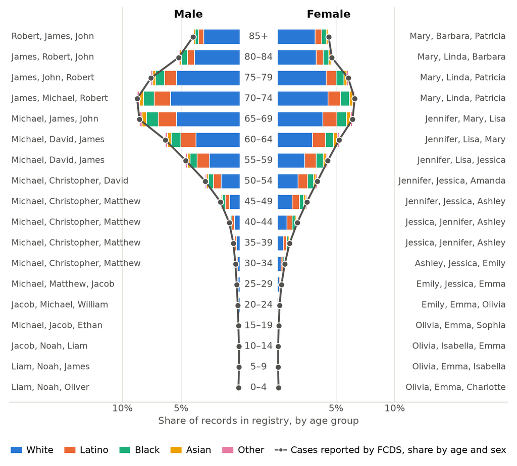

Figure 1: Who is in the simulated registry. Share of registry records by age group and sex, stacked by race/ethnicity. Dots are the age and sex distribution of cases reported to FCDS, which the registry was drawn to match. The three most common first names in each group, as they appear in the simulated registry file, are listed beside the bars.

Figure 2 shows three of the 100,000 people who appear in both the registry and the larger finder file, chosen to illustrate the kinds of error in the files, with every field that differs between their two records highlighted. The first person has a first name recorded as a nickname, a date of birth damaged on both sides, and errors in three further fields. The second has an address altered in two fields, a wrong race/ethnicity category, and a blank SSN. The third has a swapped month and day of birth, a blank state, and a swapped pair of SSN digits.

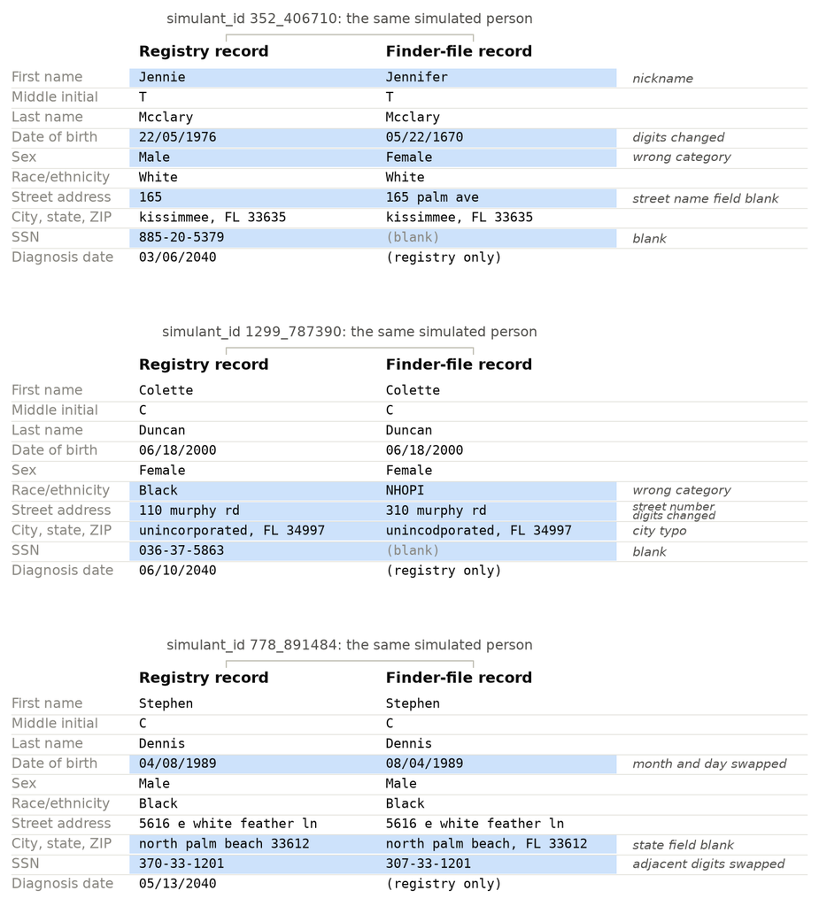

Figure 2: Simulated people as they appear in the registry and in the 500,000-record finder file. Highlighted fields differ between the two records because of the errors noted on the right.

## 3.2 Error structure

Table 1 gives the error structure field by field for the registry and the larger finder file. The smaller finder file matches the larger on every figure in the table to within 0.6 percentage points.

SSNs are blank in 20.0% of finder records, the rate specified in our design, but in 5.74% of registry records, exceeding our target of 5%. The excess of blank SSNs comes from pseudopeople, in which the share of people who never held an SSN varies with age and exceeds our target at ages 40 to 79, where most of the registry’s people are. In the larger finder file, the SSN is blank for 28.9% of Asian people and 23.4% of Latino people, compared with 17.8% of White people, and in the registry the corresponding shares are 21.5%, 15.2%, and 1.9%. Of the SSNs present in the larger finder file, 4,000 (1.0%) have two adjacent digits swapped, and of those present in the registry, 23,520 (0.5%) have one wrong digit. Where a true match has an SSN on both sides, the two agree in 98.7% of pairs.

Names and dates of birth disagree more often than SSNs do. Among true matches with both values present, first names agree in 94.0% of pairs, last names in 95.9%, and dates of birth in 93.4%. Each of these fields is blank on either side in about 2.0% of true matches. Taken together, 79.2% of true matches agree exactly on first name, last name, and date of birth, and 77.7% have an SSN on both sides that agrees. Street names agree in 97.0% of pairs with both present and are blank on either side in 5.8%. Across the six address fields, the two records have the same address in 88.6% of the pairs in which no field is blank on one side only. The unit number is blank for 94% of registry records, because most addresses have none, and street numbers are blank more often than their target rate because many are already blank in pseudopeople.

Dates of birth are blank in 1.0% of registry records, and 1.4% of those present do not parse as a calendar date (a month above 12, for example). A Doe-pattern name (John or Jane Doe) appears on 12 registry records, no SSN in any file is a single repeated digit, and 63 SSNs in the larger finder file and 341 in the registry fall in ranges that the Social Security Administration does not issue.

Table 1: Error structure by field. Blank shares in the registry and the 500,000-record finder file, with the target blanking rate for each field in parentheses; and, among the 100,000 true matches, the share of pairs whose two records agree exactly when both have a value and the share with a blank on either side. Registry SSNs and, in both files, street and unit numbers include blanks already present in the source population, so they sit above the target rates.

| Field | Blank, registry (target) | Blank, finder file (target) | True matches: agree when both present | True matches: blank on either side |
| --- | --- | --- | --- | --- |
| First name | 1.0% (1%) | 1.0% (1%) | 94.0% | 2.0% |
| Middle initial | 1.0% (1%) | 1.0% (1%) | 99.8% | 2.0% |
| Last name | 1.0% (1%) | 1.0% (1%) | 95.9% | 2.0% |
| Date of birth | 1.0% (1%) | 1.0% (1%) | 93.4% | 2.0% |
| Sex | 1.0% (1%) | 1.0% (1%) | 98.1% | 1.9% |
| Race/ethnicity | 1.0% (1%) | 1.0% (1%) | 98.1% | 2.0% |
| Street number | 5.6% (1%) | 9.5% (5%) | 98.4% | 10.3% |
| Street name | 1.0% (1%) | 5.0% (5%) | 97.0% | 5.8% |
| Unit number | 94.2% (1%) | 94.3% (5%) | 98.3% | 94.4% |
| City | 1.0% (1%) | 5.0% (5%) | 97.2% | 5.9% |
| State | 1.0% (1%) | 5.0% (5%) | 98.0% | 5.8% |
| ZIP code | 1.0% (1%) | 5.0% (5%) | 97.4% | 5.9% |
| SSN | 5.7% (5%) | 20.0% (20%) | 98.7% | 21.3% |

## 3.3 Linkage difficulty

We began by measuring how often a combination of fields uniquely identifies a person. Among the 5,000,000 people in the registry, 53.3% have a full name that no one else in the file shares, 97.0% have a first name, last name, and date of birth that no one else in the file shares, 88.8% have a unique last name and date of birth, and 81.6% a unique ZIP code, date of birth, and sex.

Table 2 scores exact-agreement rules on the larger finder file against the ground truth. The 11 rules run in 3.9 seconds on this file with 8 threads. On the smaller finder file, every rule’s recall is within 0.8 percentage points of the larger file’s.

Table 2: Exact-agreement rules on the 500,000-record finder file, scored against the ground truth. Guide rows are exact agreement on the field sets the FCDS Procedure Guide requires in a submission [7], and layout rows on the two sets of FCDS’s current Data Linkage Record Layout [23]; neither is the registry’s own matching procedure. The missed-match rate is one minus recall and the false-match rate is one minus precision.

| Rule | Predicted pairs | True | False | Recall | Missed-match | Precision | False-match |
| --- | --- | --- | --- | --- | --- | --- | --- |
| First name, last name, date of birth | 79,418 | 79,243 | 175 | 79.2% | 20.8% | 99.78% | 0.22% |
| First name, last name, date of birth, sex | 76,351 | 76,181 | 170 | 76.2% | 23.8% | 99.78% | 0.22% |
| SSN alone | 77,709 | 77,687 | 22 | 77.7% | 22.3% | 99.97% | 0.03% |
| Guide set: name, SSN, sex | 64,621 | 64,621 | 0 | 64.6% | 35.4% | 100.00% | 0.00% |
| Guide set: name, month and year of birth, sex | 80,996 | 76,616 | 4,380 | 76.6% | 23.4% | 94.59% | 5.41% |
| Either Guide set | 86,168 | 81,788 | 4,380 | 81.8% | 18.2% | 94.92% | 5.08% |
| Layout set: name, sex, date of birth, SSN | 59,124 | 59,124 | 0 | 59.1% | 40.9% | 100.00% | 0.00% |
| Layout set: name, sex, date of birth, ZIP code, street address | 56,221 | 56,221 | 0 | 56.2% | 43.8% | 100.00% | 0.00% |
| Either layout set | 71,691 | 71,691 | 0 | 71.7% | 28.3% | 100.00% | 0.00% |
| Name and date of birth, or SSN | 95,657 | 95,460 | 197 | 95.5% | 4.5% | 99.79% | 0.21% |
| Last name and date of birth | 121,878 | 86,043 | 35,835 | 86.0% | 14.0% | 70.60% | 29.40% |

Figure 3 splits three rules by the race/ethnicity recorded on the finder record. For first name, last name, and date of birth, the missed-match rate is similar across groups, from 20.5% to 21.6%, and the false-match rate stays below 0.42% in every group. The SSN rule misses 34% of true matches for Asian people and 29% for Latino people, compared with 19% for White people. The difference persists in the rule that accepts either name and date of birth or SSN, which misses 6.8% of true matches for Asian people and 3.9% for White people.

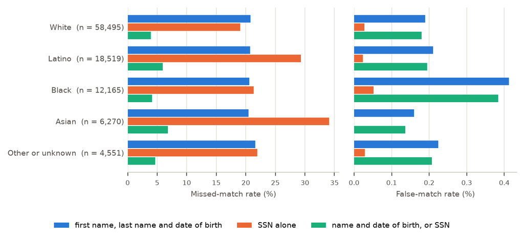

Figure 3: Missed-match and false-match rates of three exact-agreement rules on the 500,000-record finder file, by the race/ethnicity recorded on the finder record, with the number of true matches in each group.

Without blocking, the registry and the larger finder file present 2.5 trillion record pairs. Blocking on the full date of birth leaves 59 million candidate pairs and keeps 91.5% of true matches, the pairs whose dates of birth are present on both sides and agree (Table 1). Blocking on the first letter of the last name and the year of birth leaves 1.24 billion candidate pairs and keeps 90.7% of true matches.

# 4 Discussion

The files are the size of a large state registry, and the simulated registry matches the age and sex pattern of FCDS’s cases. Every record has a `simulant_id` that gives the ground truth, and the files are available as a direct download, with none of the approval processes that have kept linkage test data out of reach. We know of no other open linkage test set that combines these properties.

Deterministic linkage of these files with the exact-agreement rules of Table 2 reaches recalls from 56% to 95% at precisions above 94%, except that last name with date of birth has lower precision. This is a baseline for comparison with probabilistic methods.

There are at least four limitations in the simulated data. First, there is no simulation of a person’s life between records, so the two records of a true match differ only in their injected noise, which might make matching too easy. Second, the noise is simplistic, because it is independent across fields and files, and the mechanisms are limited to those described in Section 2.3. Third, diagnosis dates heap on three calendar years, which leaves age at diagnosis right but gives an unrealistic pattern of registry volume by year. Fourth, each file has one row per person, so within-file duplicate detection is not easily tested with this resource. Each of these was a choice we made for simplicity, and future versions might address them. Drawing some registry records from an earlier census than the finder file, for example, would let a specified share of true matches change address between their two records, and more complex noise types could also be implemented.

The differences between race/ethnicity groups shown in Section 3.3 follow from the pseudopeople population, in which the share of people with no SSN differs by race/ethnicity. The names come from the same population, in which first names are not conditioned on race/ethnicity, and the “heavy tail” of uncommon names is not as heavy as in real data [20].

This simulated data is designed for linking a finder file to a registry, and it lacks some of the detail that real files have. There are no telephone numbers or email addresses, and the addresses are not real places. The names, addresses, and households are those of the United States around 2020, so a conclusion about a name comparator reached using these files might not generalize to registries with a non-Latin alphabet or even to registries with a sufficiently different distribution of names.

Nothing in these files is confidential, even though it may appear otherwise. The simulation was initialized from public-use data that had already passed through the Census Bureau’s disclosure protections. With millions of simulated Floridians, however, some combinations of name, date of birth, and city will match real people by chance [24].

# 5 Data Access

The files are deposited on Zenodo under a DOI. The pipeline that built them is archived under its own DOI and linked from the deposit, but rerunning it requires access to the pseudopeople simulated population, which is available on request.

The corresponding author is the contact for questions, corrections, objections, and proposals for extensions, which we welcome.

# 6 Conclusions

We have built and released a set of simulated data files for testing record-linkage approaches on challenges similar to those the Florida cancer registry faces. Since the data is simulated, we were able to include the ground truth in the files, and we used it to measure the quality of several deterministic linkages. We hope the files will be used to benchmark and tune linkage software, to study differential linkage error, and to teach. The challenge of linking administrative data also appears in vital statistics systems, in cohort follow-up for drug epidemiology, and beyond health in disciplines such as social work and economics, and simulated data might be of use in all of these settings as well.

# Statements

## AI statement

We used AI assistance throughout this project: Claude models from Anthropic, through the Claude Code assistant, helped write and run the data pipeline and the analysis code, create the figures, and draft and edit this profile. The simulated records themselves are not the output of a language model; they come from the pseudopeople microsimulation described in Section 2. Every number in the profile is computed from the released files or the build’s own summaries rather than written by an AI. We take full responsibility for the content.

## References

1.

Parkin DM. The evolution of the population-based cancer registry. Nature Reviews Cancer 2006;6:603–12. https://doi.org/10.1038/nrc1948

2.

GBD 2023 Cancer Collaborators. The global, regional, and national burden of cancer, 1990–2023, with forecasts to 2050: A systematic analysis for the Global Burden of Disease Study 2023. The Lancet 2025;406:1565–86. https://doi.org/10.1016/S0140-6736(25)01635-6

3.

Florida Cancer Data System. The Florida Cancer Data System home page [Internet]. 2026; Available from: https://fcds.med.miami.edu/inc/welcome.shtml

4.

Howe GR. Use of computerized record linkage in cohort studies. Epidemiologic Reviews 1998;20:112–21. https://doi.org/10.1093/oxfordjournals.epirev.a017966

5.

Harron K, Dibben C, Boyd J, Hjern A, Azimaee M, Barreto ML, et al. Challenges in administrative data linkage for research. Big Data & Society 2017;4:1–12. https://doi.org/10.1177/2053951717745678

6.

Doidge JC, Harron K. Demystifying probabilistic linkage: Common myths and misconceptions. International Journal of Population Data Science 2018;3. https://doi.org/10.23889/ijpds.v3i1.410

7.

Bureau of Epidemiology, Florida Department of Health. Procedure guide for studies that utilize patient identifiable data from the Florida Cancer Data System [Internet]. Tallahassee, FL: Florida Department of Health; 2007. Available from: https://www.floridahealth.gov/wp-content/uploads/2025/07/request-guide.pdf

8.

North American Association of Central Cancer Registries. Cancer registries: Secondary data sharing fact sheet [Internet]. North American Association of Central Cancer Registries; 2023. Available from: https://www.naaccr.org/wp-content/uploads/2023/02/Cancer-Registry-Secondary-Data-Sharing-Fact-Sheet_Final_2.9.23.pdf

9.

Buchanich JM, Youk AO, Marsh GM, Bornemann Z, Lacey SE, Kennedy KJ, et al. Methodological issues in a retrospective cancer incidence study. American Journal of Epidemiology 2009;170:112–9. https://doi.org/10.1093/aje/kwp091

10.

Harron KL, Doidge JC, Knight HE, Gilbert RE, Goldstein H, Cromwell DA, et al. A guide to evaluating linkage quality for the analysis of linked data. International Journal of Epidemiology 2017;46:1699–710. https://doi.org/10.1093/ije/dyx177

11.

Christen P. Febrl: A freely available record linkage system with a graphical user interface. In: Proceedings of the 14th ACM SIGKDD international conference on knowledge discovery and data mining. 2008. p. 1065–8. https://doi.org/10.1145/1401890.1402020

12.

Tran K-N, Vatsalan D, Christen P. GeCo: An online personal data generator and corruptor. In: Proceedings of the 22nd ACM international conference on information & knowledge management (CIKM ’13). San Francisco, CA, USA: 2013. p. 2473–6. https://doi.org/10.1145/2505515.2508207

13.

Hildebrandt K, Panse F, Wilcke N, Ritter N. Large-scale data pollution with Apache Spark. IEEE Transactions on Big Data 2020;6:396–411. https://doi.org/10.1109/TBDATA.2016.2637378

14.

Saeedi A, Nentwig M, Peukert E, Rahm E. Scalable matching and clustering of entities with FAMER. Complex Systems Informatics and Modeling Quarterly 2018;61–83. https://doi.org/10.7250/csimq.2018-16.04

15.

Binette O, Steorts RC. (Almost) all of entity resolution. Science Advances 2022;8:eabi8021. https://doi.org/10.1126/sciadv.abi8021

16.

Schmidtmann I, Hammer G, Sariyar M, Gerhold-Ay A. Record linkage comparison patterns. 2011; https://doi.org/10.24432/C51K6B

17.

Schnell R, Weiand SV. Microsimulation of an educational attainment register to predict future record linkage quality. International Journal of Population Data Science 2023;8. https://doi.org/10.23889/ijpds.v8i1.2122

18.

Keyes O, Flaxman AD. New ways of thinking about data governance. Interactions 2026;33:24–7. https://doi.org/10.1145/3774948

19.

Alexandersson A. A feasibility study of the Python package splink for probabilistic record linkage (2023 monograph supplement) [Internet]. Florida Cancer Data System; 2023. Available from: https://fcds.med.miami.edu/downloads/RecordLinkageMonograph/2023/splink_monograph_2023_supplement.pdf

20.

Haddock B, Pletcher A, Blair-Stahn N, Keyes O, Kappel M, Bachmeier S, et al. Simulated data for census-scale entity resolution research without privacy restrictions: A large-scale dataset generated by individual-based modeling. Gates Open Research 2024;8:36. https://doi.org/10.12688/gatesopenres.15418.2

21.

Florida Cancer Data System. Florida statewide cancer registry: General incidence by sex and five-year age group, diagnosis years 1995–2023, all malignant sites [data extract] [Internet]. 2026; Available from: https://fcds.med.miami.edu/inc/statistics.shtml

22.

U.S. Census Bureau. Table 2. Resident population for the 50 states, the District of Columbia, and Puerto Rico: 2020 Census [Internet]. 2021 Apr.; Available from: https://www2.census.gov/programs-surveys/decennial/2020/data/apportionment/apportionment-2020-table02.pdf

23.

Florida Cancer Data System. Data linkage record layout [Internet]. 2021; Available from: https://fcds.med.miami.edu/downloads/datarequest/Data%20Linkage%20Record%20Layout.pdf

24.

Suchow JW, Gürkan N. Coincidental generation [Internet]. 2023; Available from: https://arxiv.org/abs/2304.01108. https://doi.org/10.48550/arXiv.2304.01108